# Determining breeding origins of migratory birds using stable hydrogen isotopes

The problem is that relative abundance serves as a very strong prior. To illustrate why, it’s useful to go back to the likelihood. Our isotope-only assignment did not explicity contain any prior information, which is equivilent to saying that each breeding cell has the same prior probability. Statistically, we would call this a uniform prior.

When we use relative abundance as a prior, we change the uniform distribution of the prior quite dramatically:

```
## stat_bin: binwidth defaulted to range/30. Use 'binwidth = x' to adjust this.
```

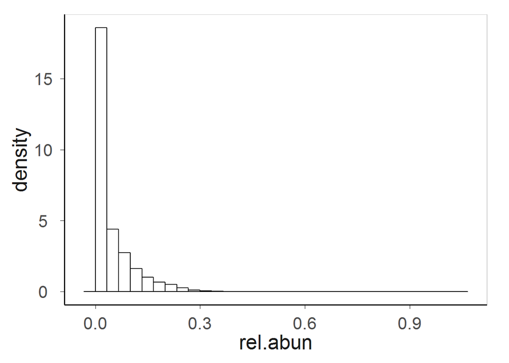

```r
   ggplot(data = amre_base) + geom_histogram(aes(x = rel.abun, y = ..density..),
                                           color = "black", fill = "white")
```

As you can see, the vast majority of the cells have a prior probability of 0 (or very close to it). When we multiply the likelihood by this prior, the posterior will also be 0 (or very close to it). Thus, our two approaches sit at opposite ends of the Bayesian spectrum. The likelihood approach imposes no prior information on our assignments (what is usually called an *uninformative prior*), whereas the abundance a very strong (i.e. very *informative*) prior on the assignments. Neither approach is wrong (one can make a logical argument in favor of either approach and both are statistically valid) but neither approach is ideal (*side note: this issue actually captures one of the major debates between frequentists and Bayesians. That is, is it appropriate to shape your inference based on information other than your data? But that’s a subject for a different lecture). The resolution of the isotope-only approach leaves much to be desired but including abundance data will lead to very inaccurate assignments (except for the few individuals that do happen to come from the high abundance sites). We can see just how inaccurate using the known-origin birds:

```r
## Incorporate abundance into isotope assignments
  nc.abun.assign <- abun_assign(iso.like = nc.assign$iso.like, rel.abun = amre_base$rel.abun,
                                iso.weight = 0, abun.weight = 0)
  la.abun.assign <- abun_assign(iso.like = la.assign$iso.like, rel.abun = amre_base$rel.abun,
                                iso.weight = 0, abun.weight = 0)
  vt.abun.assign <- abun_assign(iso.like = vt.assign$iso.like, rel.abun = amre_base$rel.abun,
                                iso.weight = 0, abun.weight = 0)
  md.abun.assign <- abun_assign(iso.like = md.assign$iso.like, rel.abun = amre_base$rel.abun,
                                iso.weight = 0, abun.weight = 0)
  mi.abun.assign <- abun_assign(iso.like = mi.assign$iso.like, rel.abun = amre_base$rel.abun,
                                iso.weight = 0, abun.weight = 0)
  mo.abun.assign <- abun_assign(iso.like = mo.assign$iso.like, rel.abun = amre_base$rel.abun,
                                iso.weight = 0, abun.weight = 0)

## Estimate error rate for each site
  # North Carolina
  error_rate(origin = nc.abun.assign$origin, origin.cell = nc$origin)
```

```
## [1] 1
```

```r
# Louisiana
  error_rate(origin = la.abun.assign$origin, origin.cell = la$origin)
```

```
## [1] 0.85
```

```r
# Vermont
  error_rate(origin = vt.abun.assign$origin, origin.cell = vt$origin)
```

```
## [1] 1
```

```r
# Maryland
  error_rate(origin = md.abun.assign$origin, origin.cell = md$origin)
```

```
## [1] 1
```

```r
# Michigan
  error_rate(origin = mi.abun.assign$origin, origin.cell = mi$origin)
```

```
## [1] 1
```

```r
# Missouri
  error_rate(origin = mo.abun.assign$origin, origin.cell = mo$origin)
```

```
## [1] 1
```

Nearly 100% of birds are misclassified! Hopefully you’re convinced that this approach to including abundance does not work (and that it is critical to validate your model!).

Even though the above model does not work very well, there is still sound logical and practical arguements for including abundance. Logically, low abundance sites *should* get lower prior probability because birds are less likely to come from them. Practically, we would still like to improve the resolution of our isotope-based assignments. One solution to this problem is to try to make the prior less informative, which we can do by down-weighting the abundance data. This down-weighting is done by raising the relative abundance data to a power between 0 and 1. We do not have time to explore the right weighting in this lab but we have done this and found that a weighting of around 0.13 works pretty well for redstarts (interestingly, slightly down-weighting the isotope data by 0.79 also improves the model). To see what this down-weighting does, let’s visualize the down-weighted prior distribution of abundance values:

```
## stat_bin: binwidth defaulted to range/30. Use 'binwidth = x' to adjust this.
```

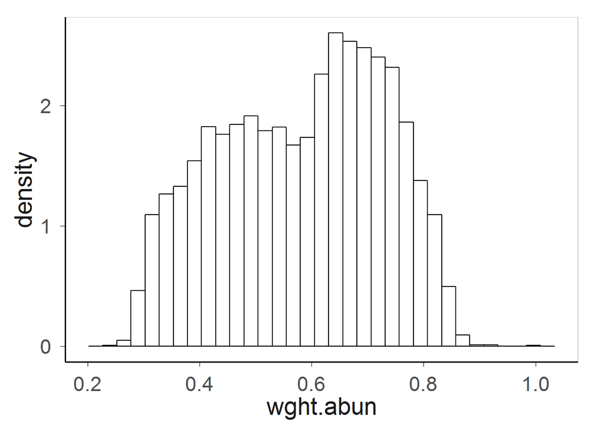

```r
   # Add a new column to the base map by raising the relative abundance values to 0.1259
   weight <- 10^-0.9
   amre_base %<>% mutate(wght.abun = rel.abun^weight)

   ggplot(data = amre_base) + geom_histogram(aes(x = wght.abun, y = ..density..),
                                           color = "black", fill = "white")
```

As you can see, we have effectively “smoothed” out the abundance distribution: low abundance sites are still down-weighted but overall the distribution is more uniform (the isotope down-weighting does the same thing but to a lesser extent).

The abun_assign() function allows to easily incorporate this weighting into the assignments (note that the weights are given as log(weight, base = 10)):

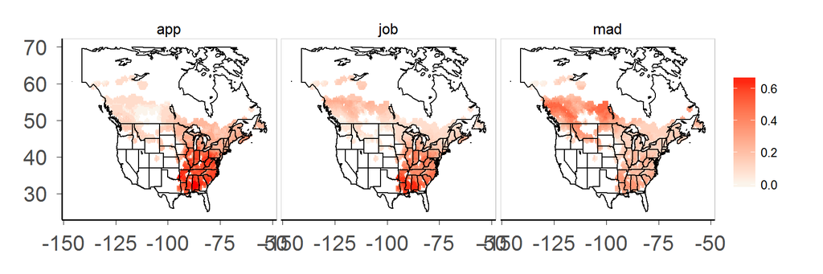

```r
     ## Assignment
  app_abun <- abun_assign(iso.like = app_assign$iso.like, rel.abun = amre_base$rel.abun,
                          iso.weight = -0.1, abun.weight = -0.9)
  job_abun <- abun_assign(iso.like = job_assign$iso.like, rel.abun = amre_base$rel.abun,
                          iso.weight = -0.1, abun.weight = -0.9)
  mad_abun <- abun_assign(iso.like = mad_assign$iso.like, rel.abun = amre_base$rel.abun,
                          iso.weight = -0.1, abun.weight = -0.9)

  # Recombine and tidy

  abun.assign <- data.frame(Latitude = amre_base$lat,
                            Longitude = amre_base$long,
                            app_origin = apply(app_abun$origin, 1,sum)/ncol(app_abun$origin),
                            job_origin = apply(job_abun$origin, 1,sum)/ncol(job_abun$origin),
                            mad_origin = apply(mad_abun$origin, 1,sum)/ncol(mad_abun$origin))

  abun_tidy <- abun.assign %>% gather(site, origin.prob, -Latitude, -Longitude) %>%
    separate(site, into = c("site", "origin"), sep = "\\_") %>%
    select(-origin)

  # Plot assignments
  abun_map <- ggplot() +
        geom_raster(data = abun_tidy, aes(x = Longitude, y = Latitude, fill = origin.prob)) +
        geom_polygon(data=all_states, aes(x=long, y=lat, group = group),colour="black", fill =NA) +
        geom_polygon(data=all_countries, aes(x=long, y=lat, group = group),colour="black", fill =NA) +
        scale_fill_gradient(low = "#fbf4eb", high = "red") +
        facet_wrap(~site, nrow = 1) +
        theme(axis.title = element_blank())
  abun_map
```

As you can see, this weighting mostly preserves the patterns we observed with the isotope-only assignments. However, the precision of our new assignments is slightly improved:

```r
## Appalachicola (isotope-only vs. abundance)
  area_assign(app_assign$iso.origin)
```

```
## [1] 0.2709
```

```r
  area_assign(app_abun$origin)
```

```
## [1] 0.2507
```

```r
## Johnson's Bayou (isotope-only vs. abundance)
  area_assign(job_assign$iso.origin)
```

```
## [1] 0.228
```

```r
  area_assign(job_abun$origin)
```

```
## [1] 0.2007
```

```r
## Mad Island (isotope-only vs. abundance)
  area_assign(mad_assign$iso.origin)
```

```
## [1] 0.2595
```

```r
  area_assign(mad_abun$origin)
```

```
## [1] 0.2298
```

For redstarts, it turns out that the gain in precision is pretty small when abundance is added to the model. However, for other species the gain can be pretty big (~20%). However, it must be noted that it is impossible to add abundance without at least slightly increasing assignment error; it is simply a fact of the model that birds from low abundance sites will have a lower probability of being assigned to their correct breeding location. Thus, although abundance data can help improve the resolution of assignments models, the real improvements to model accuracy **and** precision come from adding additional sources of data (e.g., other isotopes, genetic data, morphological traits). See readings below for examples of these approaches.

## Citations

Hallworth, M. T., Studds, C. E., Scott Sillett, T., & Marra, P. P. (2013). Do archival light-level geolocators and stable hydrogen isotopes provide comparable estimates of breeding-ground origin?. The Auk, 130(2), 273-282.

Hobson, K. A., Van Wilgenburg, S. L., Wassenaar, L. I., & Larson, K. (2012). Linking hydrogen (Î´ 2 H) isotopes in feathers and precipitation: sources of variance and consequences for assignment to isoscapes. PLoS One, 7(4), e35137.

## Further reading:

Royle, A.J., & Rubenstein, D. R. (2004). The role of species abundance in determining breeding origins of migratory birds with stable isotopes. Ecological Applications, 14(6), 1780-1788.

Ruegg, K. C., Anderson, E. C., Paxton, K. L., Apkenas, V., Lao, S., Siegel, R. B., … & Smith, T. B. (2014). Mapping migration in a songbird using highâresolution genetic markers. Molecular ecology, 23(23), 5726-5739.

Rundel, C. W., Wunder, M. B., Alvarado, A. H., Ruegg, K. C., Harrigan, R., Schuh, A., … & Novembre, J. (2013). Novel statistical methods for integrating genetic and stable isotope data to infer individualâlevel migratory connectivity. Molecular Ecology, 22(16), 4163-4176.

Rushing, C. S., Ryder, T. B., Saracco, J. F., & Marra, P. P. (2014). Assessing migratory connectivity for a long-distance migratory bird using multiple intrinsic markers. Ecological Applications, 24(3), 445-456.